# ANALYSE DE LA DEMANDE ÉLECTRIQUE : SINGAPOUR

Étude Économétrique de la Prévision (2009-2025)

Guillemette Cipriano

16 April 2026

```r
library(forecast)
library(ggplot2)
library(urca)
library(zoo)
library(lmtest)
library(FinTS)
library(TSA)
library(tseries)
```

## Chargement et préparation des données

Dans le cadre du Projet 1, les tests de racine unitaire ont permis d’identifier la nature du processus générateur de données (PGD). Plus précisément, l’application du test de Lee et Strazicich conclut à la présence d’un PGD de type DS (Difference Stationary). Ce test met également en évidence deux date de rupture structurelle survenue en septembre 2011 et en août 2019, lesquelles se caractérisent par une modification simultanée du niveau et de la tendance (pente) de la série temporelle.

```r
## Chargement et préparation des données

data = read.csv("monthly_full_release_long_format(1).csv",sep = ";")
data_filter = subset(data, Area == "Singapore")
data_demand = subset(data_filter, Variable == "Demand")
electricite12= ts(data_demand$Value, start = c(2009, 1), freq = 12)
electricite_2=diff(electricite12,12)
dX=diff(electricite_2)
```

### Chronogramme de la série

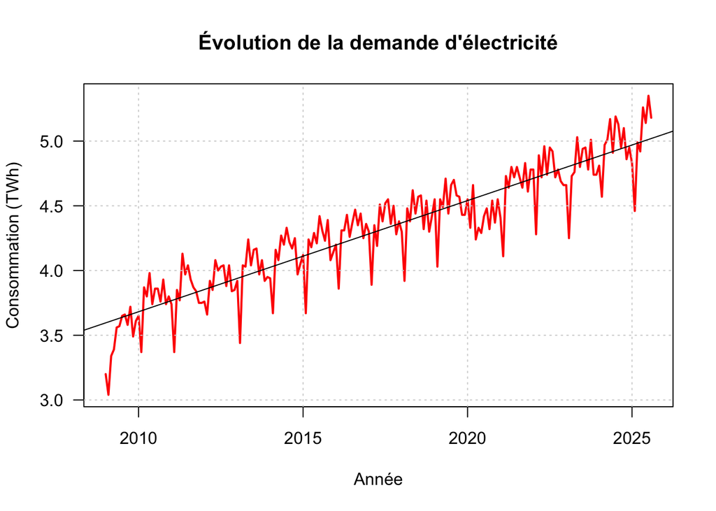

```r
plot.ts(electricite12,
        main = "Évolution de la demande d'électricité",
        ylab = "Consommation (TWh)",
        xlab = "Année",
        col = "red",
        lwd = 2,
        las = 1)
grid()
abline(lm((electricite12 ~time(electricite12))))
```

## 1. Prévision sur la série issue du PGD stationnaire

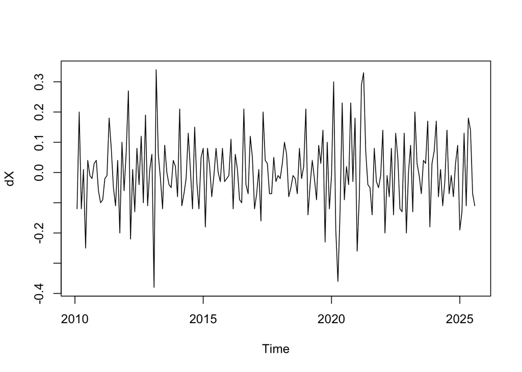

```r
plot(dX)
```

L’analyse graphique de la série différenciée confirme l’obtention d’un processus stationnaire. Ses fluctuations sont stables et centrées sur une constante nulle (E(Xt)≈0).

## 1.1. Estimation du modèle

Autocrrélation : ACF / PACF / eacf

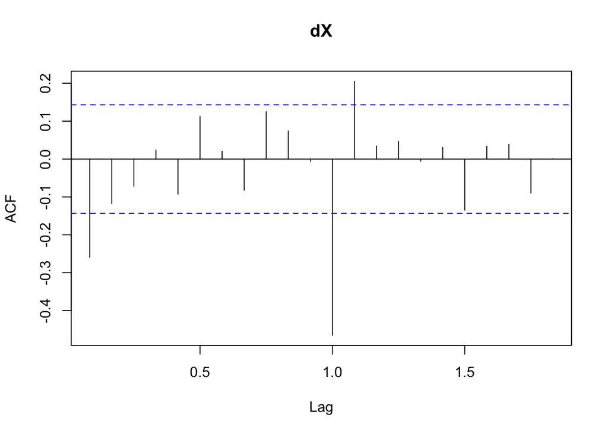

```r
Acf(dX)
```

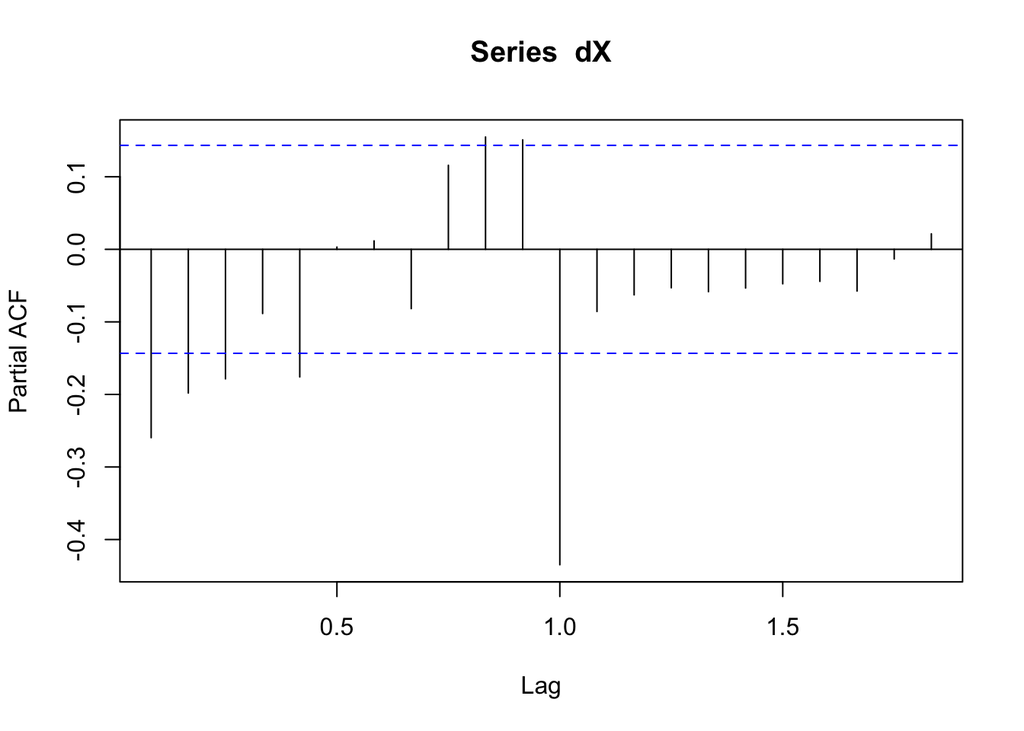

```r
pacf(dX)
```

L’analyse des corrélogrammes permet d’orienter le choix de la structure du modèle. L’examen de la fonction d’autocorrélation (ACF) révèle des pics significatifs aux retards 1, 12 et 13. Parallèlement, la fonction d’autocorrélation partielle (PACF) affiche des autocorrélations significatives aux ordres 1, 2, 3, 5, 10, 11 et 12.

```r
eacf(dX)
```

```
## AR/MA
##   0 1 2 3 4 5 6 7 8 9 10 11 12 13
## 0 x o o o o o o o o o o  x  x  o
## 1 x o o o o o o o o o o  x  x  o
## 2 x o o o o o o o o o o  x  x  x
## 3 x x x o o o o o o o o  x  x  x
## 4 x x o o o o o o o o o  x  x  o
## 5 o o x x x o o o o o o  x  x  x
## 6 x o o x o o o o o o o  x  x  o
## 7 o o o x o o o o o o o  x  o  o
```

L’analyse de la matrice EACF permet de déterminer les ordres optimaux du modèle en s’appuyant sur la règle du coin supérieur gauche. Le sommet du triangle formé par les coefficients statistiquement nuls se situant aux coordonnées p=6 et q=13, la spécification ARMA(6,13) est privilégiée pour l’étape d’estimation.

:
$$X_t = \phi_0 + \sum_{i=1}^{6} \phi_i
X_{t-i} + \varepsilon_t + \sum_{j=1}^{13} \theta_j \varepsilon_{t-j}$$

```r
reg<-Arima(dX,order=c(6,0,13),include.mean=F,fixed=c(0,0,0,0,0,0,NA,0,0,0,0,0,0,0,0,0,0,NA,NA))
coeftest(reg)
```

```
##
## z test of coefficients:
##
##       Estimate Std. Error z value  Pr(>|z|)
## ma1  -0.430996   0.089967 -4.7906 1.663e-06 ***
## ma12 -1.037830   0.142373 -7.2895 3.110e-13 ***
## ma13  0.470718   0.108408  4.3421 1.411e-05 ***
## ---
## Signif. codes:  0 '***' 0.001 '**' 0.01 '*' 0.05 '.' 0.1 ' ' 1
```

Validation des coefficients du modèle ARMA(0,13)

$H_0$ : Le coefficient testé est nul. $H_a$ : Le coefficient testé est différent de zéro.

En appliquant une méthode d’élimination pas-à-pas (détaillée en annexe), nous avons épuré le modèle initial pour aboutir à une spécification ARMA(0,13) restreinte. Celle-ci ne conserve que les variables pertinentes : Ma(1), MA(12) et MA(13).

Toutes les p-values de ces coefficients sont en dessous du seuil de 5 % (0.05), l’hypothèse nulle (H0) est rejetée. Les coefficients de notre modèle final sont donc rigoureusement significatifs.

## 1.2. Validation du modèle

Afin de valider définitivement la spécification retenue, il est impératif de s’assurer que le processus des résidus (εt) se comporte comme un bruit blanc. Cette étape de diagnostic nécessite la vérification rigoureuse de trois conditions fondamentales :

- Une espérance mathématique nulle (E(εt)=0).
- L’absence d’autocorrélation temporelle.
- L’homoscédasticité, c’est-à-dire une variance constante au cours du temps.

#### 1.2.1. Test de nullité de l’espérance (t-test)

```r
t.test(reg$res)
```

```
##
##  One Sample t-test
##
## data:  reg$res
## t = -1.4273, df = 186, p-value = 0.1552
## alternative hypothesis: true mean is not equal to 0
## 95 percent confidence interval:
##  -0.019044700  0.003055545
## sample estimates:
##    mean of x
## -0.007994577
```

$$H_0 : \mathbb{E}[\varepsilon_t] =
0$$

$$H_a : \mathbb{E}[\varepsilon_t] \neq
0$$

La probabilité critique (p-value) associée à ce test s’élève à 0.1552 Étant supérieure au seuil de significativité de 5 % (>0.05), nous acceptonsl’hypothèse nulle (H0). Par conséquent, la condition d’une espérance nulle des résidus est statistiquement validée.

#### 1.2.2. ACF / PACF : test Ljung-Box

Afin de vérifier rigoureusement l’absence d’autocorrélation, nous procédons préalablement à la standardisation des aléas du modèle.

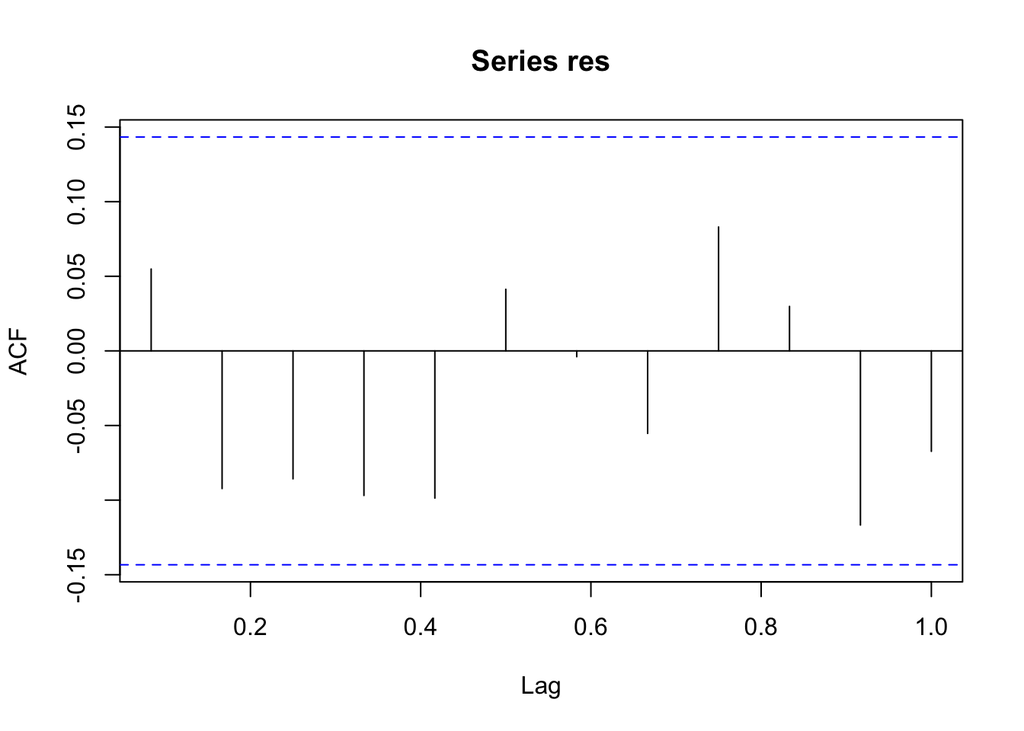

```r
res=(reg$res-mean(reg$res))/sd(reg$res)
acf(res, lag.max = 12)
```

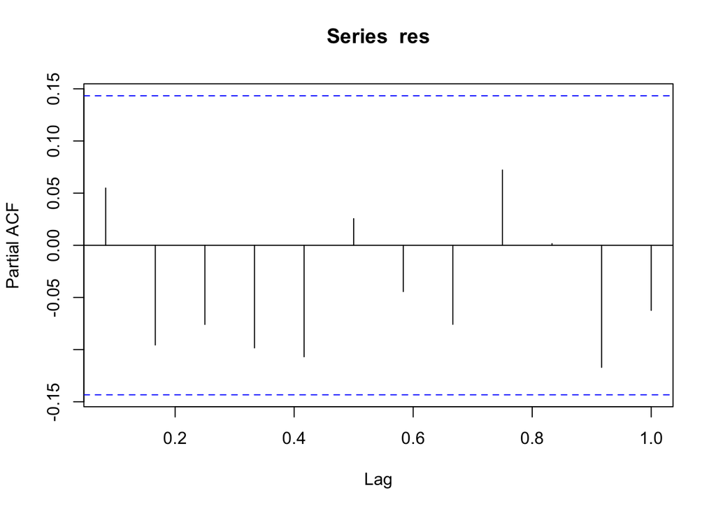

```r
pacf(res, lag.max = 12)
```

Graphiquement, l’ACF et la PACF ne montrent aucun signe d’autocorrélation des résidus. Pour corroborer ce diagnostic, nous appliquons le test de Ljung-Box.

```r
Box.test(res,lag=1,type="Ljung-Box")
```

```
##
##  Box-Ljung test
##
## data:  res
## X-squared = 0.57173, df = 1, p-value = 0.4496
```

```r
Box.test(res,lag=12,type="Ljung-Box")
```

```
##
##  Box-Ljung test
##
## data:  res
## X-squared = 13.45, df = 12, p-value = 0.3372
```

Le diagnostic final repose sur le test statistique de Ljung-Box :

$$H_0 : \rho_1 = \rho_2 = \dots = \rho_h =
0$$

$$H_a : \exists k \in \{1, \dots, h\} \mid
\rho_k \neq 0$$

#### 1.2.3. Test d’hétéroscédasticité conditionnelle (Test ARCH)

La dernière condition porte sur la constance de la variance des résidus.

```r
K<-12
 temp<-rep(0,K)
 for(i in 1:K){
 temp[i]<-ArchTest(res, lag=i)$p.value
 }
temp
```

```
##  [1] 0.0001461728 0.0006580979 0.0020045647 0.0054173160 0.0079099133
##  [6] 0.0094620539 0.0191080981 0.0194708244 0.0198904321 0.0235066638
## [11] 0.0307548459 0.0344031541
```

$$H_0 : \text{Homoscédasticité
conditionnelle des aléas}$$
$$H_a :
\text{Hétéroscédasticité conditionnelle des aléas}$$

$$H_0 : \text{Homoscédasticité
conditionnelle des aléas}$$
$$H_a :
\text{Hétéroscédasticité conditionnelle des aléas}$$

#### 1.2.4. Test de normalités des aléas (Test Jacques Bera)

```r
jarque.bera.test(reg$res)
```

```
##
##  Jarque Bera Test
##
## data:  reg$res
## X-squared = 61.594, df = 2, p-value = 4.219e-14
```

$$H_0 : \varepsilon \sim \mathcal{N}(0,
\sigma_\varepsilon^2)$$
$$H_a :
\varepsilon \nsim \mathcal{N}(0, \sigma_\varepsilon^2)$$

La probabilité critique associée à ce test est asymptotiquement nulle (p-value = 4.219e-14 ). Étant très largement inférieure au seuil de 5%, nous rejetons formellement l’hypothèse nulle (H0). Les résidus ne sont donc pas distribués selon une loi normale. Sur le plan opérationnel, cette absence de normalité stricte implique que les intervalles de confiance construits classiquement autour de nos prévisions risquent d’être biaisés et perdront en fiabilité.

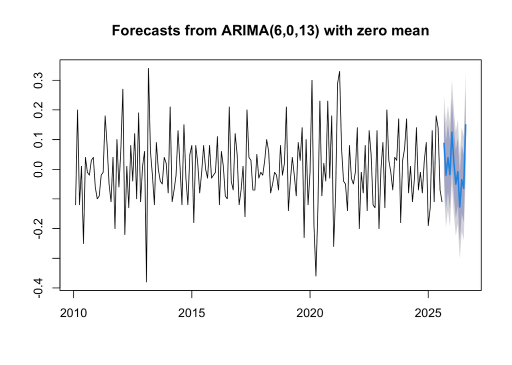

```r
prev <- forecast(reg, h = 12)
pprev <- forecast(reg,level = 0.95)
plot(prev)
```

## 2.1. estimation du modèle

```r
reg_1<-Arima(electricite_2,order=c(6,1,13),include.mean=F,fixed=c(0,0,0,0,0,0,NA,0,0,0,0,0,0,0,0,0,0,NA,NA))
coeftest(reg_1)
```

```
##
## z test of coefficients:
##
##       Estimate Std. Error z value  Pr(>|z|)
## ma1  -0.430996   0.089967 -4.7906 1.663e-06 ***
## ma12 -1.037830   0.142372 -7.2895 3.110e-13 ***
## ma13  0.470718   0.108408  4.3421 1.411e-05 ***
## ---
## Signif. codes:  0 '***' 0.001 '**' 0.01 '*' 0.05 '.' 0.1 ' ' 1
```

L’estimation de cette nouvelle spécification sur la série différenciée s’avère concluante. L’analyse des résultats montre en effet que l’ensemble des coefficients conservés dans l’équation sont statistiquement significatifs, leurs p-values étant toutes strictement inférieures au seuil de 5%.

## 2.2. validation des résidus

#### 2.2.1. Test de l’Espérance Nulle (t-test)

```r
t.test(reg_1$res)
```

```
##
##  One Sample t-test
##
## data:  reg_1$res
## t = -1.4268, df = 187, p-value = 0.1553
## alternative hypothesis: true mean is not equal to 0
## 95 percent confidence interval:
##  -0.018940811  0.003041508
## sample estimates:
##    mean of x
## -0.007949651
```

$$H_0 : \mathbb{E}[\varepsilon_t] =
0$$
$$H_a : \mathbb{E}[\varepsilon_t]
\neq 0$$

La p-value obtenue est de 0.1553. Cette valeur étant supérieure au seuil de 5%, nous acceptons l’hypothèse nulle (𝐻0). L’espérance des résidus est donc statistiquement nulle.

#### 2.2.2. Test d’Autocorrélation (Ljung-Box)

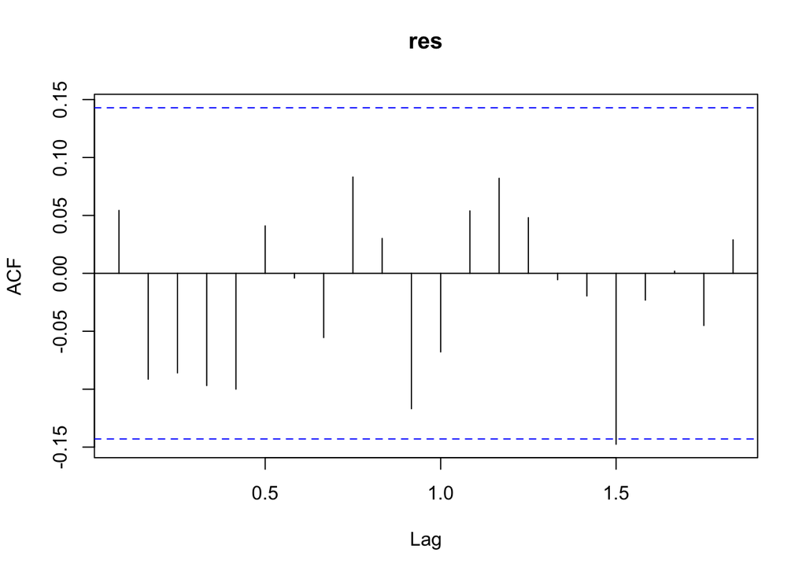

```r
res=(reg_1$res-mean(reg_1$res))/sd(reg_1$res)
Acf(res)
```

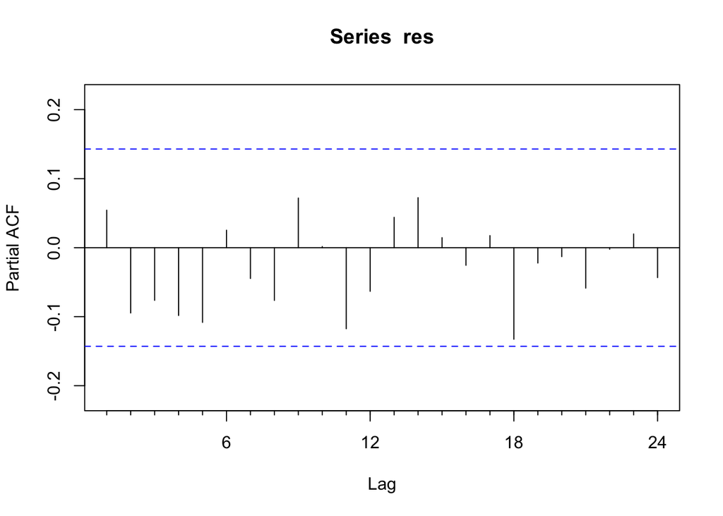

```r
Pacf(res)
```

```r
Box.test(res,lag=1,type="Ljung-Box")
```

```
##
##  Box-Ljung test
##
## data:  res
## X-squared = 0.56359, df = 1, p-value = 0.4528
```

```r
Box.test(res,lag=12,type="Ljung-Box")
```

```
##
##  Box-Ljung test
##
## data:  res
## X-squared = 13.56, df = 12, p-value = 0.3297
```

$$H_0 : \rho_1 = \rho_2 = \dots = \rho_h =
0$$

$$H_a : \exists k \in \{1, \dots, h\} \mid
\rho_k \neq 0$$

La p-value obtenue est de 0.4528 et de 0,3297. Ces valeurs étant supérieures au seuil de 5%, nous acceptons l’hypothèse nulle (𝐻0).Il n’y a pas d’autocorrélation significative des résidus.

#### 2.2.3. Test d’Hétéroscédasticité (ARCH)

```r
K<-12
 temp<-rep(0,K)
 for(i in 1:K){
 temp[i]<-ArchTest(res, lag=i)$p.value
 }
temp
```

```
##  [1] 0.0001392380 0.0006426241 0.0020927441 0.0050068774 0.0099789258
##  [6] 0.0118837582 0.0175981046 0.0185037112 0.0186727167 0.0219494269
## [11] 0.0293627458 0.0329546033
```

$$H_0 : \text{Homoscédasticité
conditionnelle des aléas}$$
$$H_a :
\text{Hétéroscédasticité conditionnelle des aléas}$$

#### 2.2.4 Test de Normalité (Jarque-Bera)

```r
jarque.bera.test(reg_1$res)
```

```
##
##  Jarque Bera Test
##
## data:  reg_1$res
## X-squared = 63.221, df = 2, p-value = 1.865e-14
```

$$H_0 : \varepsilon \sim \mathcal{N}(0,
\sigma_\varepsilon^2)$$
$$H_a :
\varepsilon \nsim \mathcal{N}(0, \sigma_\varepsilon^2)$$

Le test de Jarque-Bera affiche une p-value largement inférieure à 0.05 (P-VALUE=1.865e-14), conduisant au rejet de l’hypothèse nulle (H0) de normalité des résidus. Cette absence de distribution normale suggère que les erreurs du modèle présentent une asymétrie ou un aplatissement (kurtosis) incompatible avec une loi normale. Par conséquent, bien que les coefficients du modèle ARIMA restent sans biais, la fiabilité statistique des intervalles de prévision est altérée.

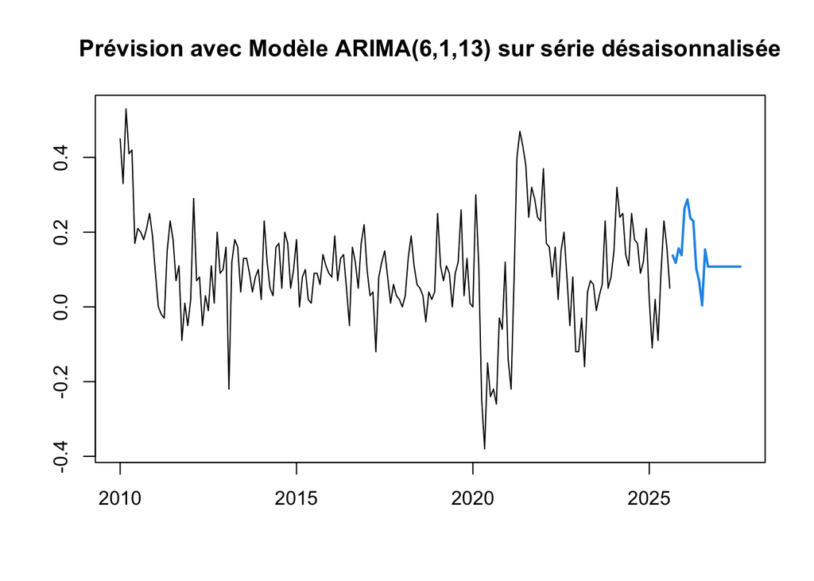

```r
prev<-forecast(reg_1,level=0.95)
plot(prev,PI=FALSE, main="Prévision avec Modèle ARIMA(6,1,13) sur série désaisonnalisée")
```

## 3.Prévision sur la série initiale (SARIMA)

La phase finale de notre étude consiste à effectuer la prévision sur la série brute initiale (electricite). Afin de prendre en compte la dynamique saisonnière complète, nous étendons la structure de notre modèle précédent en y intégrant des composantes saisonnières explicites. Nous passons ainsi d’une spécification ARIMA à un modèle SARIMA$(6,1,13)(1,1,1)_{12}$, permettant de capturer simultanément les dépendances de court terme et les cycles annuels.

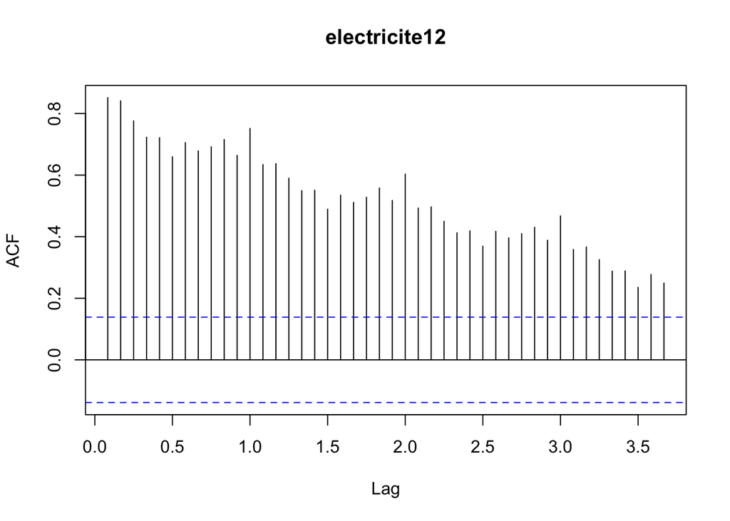

```r
Acf(electricite12,lag.max=44)
```

L’analyse de la fonction d’autocorrélation de la série initiale justifie le passage à un ordre D=1. On observe en effet que les autocorrélations aux ordres saisonniers (multiples de 12) sont très élevées et ne convergent que très progressivement vers zéro. Cette lenteur de décroissance est le signe typique d’une composante saisonnière stochastique qu’il convient de traiter par une différenciation d’ordre 1.

```r
s=12
reg_2 <- Arima(electricite12,
              order = c(6, 1, 13),
              seasonal = list(order = c(1, 1, 1), period = 12),
              fixed = c(0,0,0,0,0,0, NA,0,0,0,0,0,0,0,0,0,0,NA,NA, NA,NA))
coeftest(reg_2)
```

```
##
## z test of coefficients:
##
##        Estimate Std. Error   z value  Pr(>|z|)
## ma1  -0.4470540  0.0873820   -5.1161 3.119e-07 ***
## ma12 -1.0504071  0.1334587   -7.8707 3.528e-15 ***
## ma13  0.4976449  0.1046228    4.7566 1.969e-06 ***
## sar1 -0.9959023  0.0060431 -164.8003 < 2.2e-16 ***
## sma1  0.9785595  0.0192128   50.9327 < 2.2e-16 ***
## ---
## Signif. codes:  0 '***' 0.001 '**' 0.01 '*' 0.05 '.' 0.1 ' ' 1
```

Tous les coefficients affichent une p-value inférieure à 5%, ainsi ils sont tous significatifs.

## 3.2. validation du modèle

#### 3.2.1. Test de l’Espérance Nulle (t-test)

```r
t.test(reg_2$res)
```

```
##
##  One Sample t-test
##
## data:  reg_2$res
## t = -1.4922, df = 199, p-value = 0.1372
## alternative hypothesis: true mean is not equal to 0
## 95 percent confidence interval:
##  -0.017648438  0.002444235
## sample estimates:
##    mean of x
## -0.007602101
```

$$H_0 : \mathbb{E}[\varepsilon_t] =
0$$

$$H_a : \mathbb{E}[\varepsilon_t] \neq
0$$

La p-value obtenue est de 0.1372. Cette valeur étant supérieure au seuil de 5%, nous acceptons l’hypothèse nulle (𝐻0). L’espérance des résidus est donc statistiquement nulle.

#### 3.2.2. ACF / PACF : test Ljung-Box

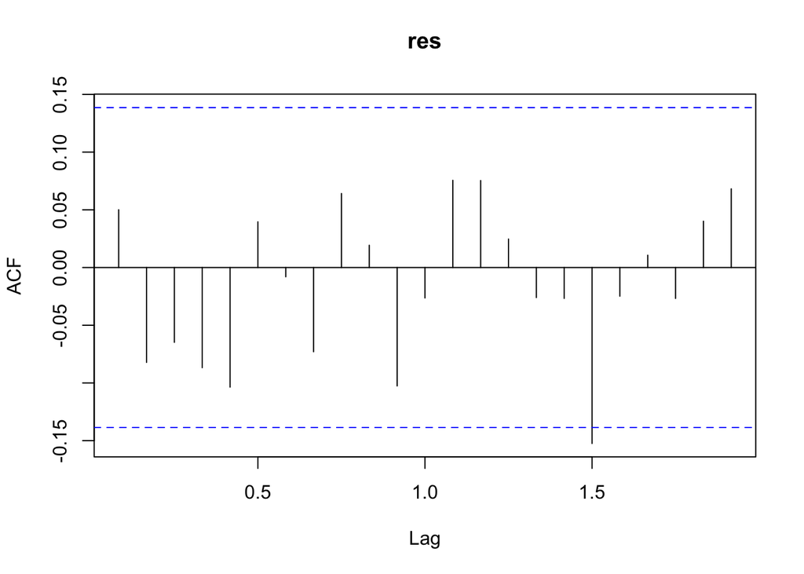

```r
res=(reg_2$res-mean(reg_2$res))/sd(reg_2$res)
Acf(res)
```

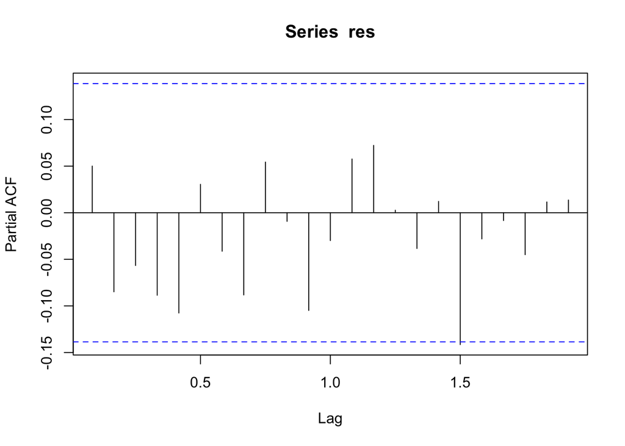

```r
pacf(res)
```

```r
Box.test(res,lag=1,type="Ljung-Box")
```

```
##
##  Box-Ljung test
##
## data:  res
## X-squared = 0.50874, df = 1, p-value = 0.4757
```

```r
Box.test(res,lag=12,type="Ljung-Box")
```

```
##
##  Box-Ljung test
##
## data:  res
## X-squared = 11.328, df = 12, p-value = 0.501
```

L’analyse repose sur le test statistique de Ljung-Box :

$$H_0 : \rho_1 = \rho_2 = \dots = \rho_h =
0$$

$$H_a : \exists k \in \{1, \dots, h\} \mid
\rho_k \neq 0$$
Pour les retards 1 et 12, le test renvoie des p-values respectives de 0.4757 et 0.501. Étant donné qu’elles excèdent le seuil de 5%, H0 est conservée : l’hypothèse d’absence d’autocorrélation des résidus est validée.

#### 3.2.3. Test d’Hétéroscédasticité (ARCH)

```r
K<-12
 temp<-rep(0,K)
 for(i in 1:K){
 temp[i]<-ArchTest(res, lag=i)$p.value
 }
temp
```

```
##  [1] 5.563319e-05 2.439881e-04 8.814241e-04 2.535591e-03 5.069436e-03
##  [6] 8.713219e-03 1.738547e-02 1.802427e-02 1.996078e-02 1.962938e-02
## [11] 2.591780e-02 2.776947e-02
```

$$H_0 : \text{Homoscédasticité
conditionnelle des aléas}$$
$$H_a :
\text{Hétéroscédasticité conditionnelle des aléas}$$

#### 3.2.4. Test de Normalité (Jarque-Bera)

```r
jarque.bera.test(reg_2$res)
```

```
##
##  Jarque Bera Test
##
## data:  reg_2$res
## X-squared = 90.556, df = 2, p-value < 2.2e-16
```

$$H_0 : \varepsilon \sim \mathcal{N}(0,
\sigma_\varepsilon^2)$$
$$H_a :
\varepsilon \nsim \mathcal{N}(0, \sigma_\varepsilon^2)$$

Le test de Jarque-Bera affiche une p-value largement inférieure à 0.05 (P-VALUE=2,2e-16), conduisant au rejet de l’hypothèse nulle (H0) de normalité des résidus. Cette absence de distribution normale suggère que les erreurs du modèle présentent une asymétrie incompatible avec une loi normale. Par conséquent,la fiabilité statistique des intervalles de prévision est altérée.

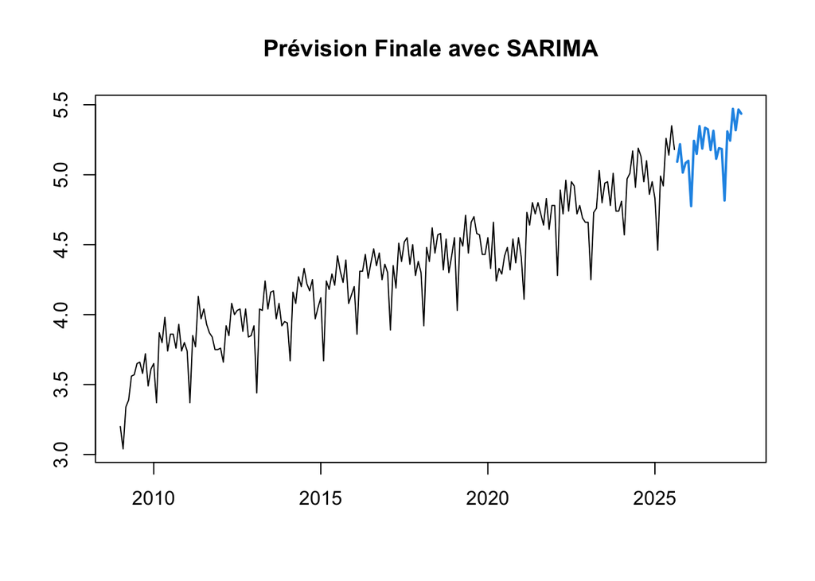

```r
prev<-forecast(reg_2,level=0.95)
plot(prev,PI=FALSE, main="Prévision Finale avec SARIMA")
```

## CONCLUSION :

L’objectif de cette étude était de modéliser et de prévoir la demande électrique singapourienne. Le processus générateur de données ayant été identifié comme Difference Stationary (DS), la série a fait l’objet d’un filtrage régulier et saisonnier. L’estimation itérative a conduit à retenir une spécification parcimonieuse SARIMA$(6,1,13)(1,1,1)_{12}$.

Bien que ce modèle neutralise avec succès l’autocorrélation des innovations, les tests de robustesse soulignent deux défaillances statistiques majeures : le rejet de l’hypothèse de normalité (Jarque-Bera) et la présence d’effets ARCH persistants. Cette hétéroscédasticité conditionnelle traduit une incapacité du cadre ARIMA classique à modéliser les pics de volatilité extrêmes.

Par conséquent, si ce modèle fournit une trajectoire de prévision ponctuelle robuste, confirmant une croissance tendancielle rythmée par de forts cycles saisonniers , ses intervalles de confiance s’en trouvent fragilisés.L’incertitude entourant les prévisions reste sous-estimée en raison de la nature non-gaussienne et volatile des chocs (climatiques et économiques) impactant la série. Elle nécéssiterait d’être modélisée via une approche de type GARCH.

## ANNEXES :

```r
reg<-Arima(dX,order=c(6,0,13))
coeftest(reg)
```

```
##
## z test of coefficients:
##
##              Estimate  Std. Error  z value Pr(>|z|)
## ar1       -0.23194240         NaN      NaN      NaN
## ar2       -0.22455480         NaN      NaN      NaN
## ar3       -0.11495559         NaN      NaN      NaN
## ar4       -0.18235134         NaN      NaN      NaN
## ar5       -0.21241953         NaN      NaN      NaN
## ar6        0.01636141         NaN      NaN      NaN
## ma1       -0.14472149         NaN      NaN      NaN
## ma2        0.02006955         NaN      NaN      NaN
## ma3       -0.06289722         NaN      NaN      NaN
## ma4        0.06551406         NaN      NaN      NaN
## ma5        0.01917655  0.01846485   1.0385   0.2990
## ma6       -0.09242100  0.08885585  -1.0401   0.2983
## ma7       -0.07688793         NaN      NaN      NaN
## ma8       -0.02711833         NaN      NaN      NaN
## ma9        0.05575822         NaN      NaN      NaN
## ma10      -0.03692590         NaN      NaN      NaN
## ma11      -0.03411971  0.08081333  -0.4222   0.6729
## ma12      -0.89670477  0.06295419 -14.2438   <2e-16 ***
## ma13       0.21132498         NaN      NaN      NaN
## intercept -0.00043461  0.00048866  -0.8894   0.3738
## ---
## Signif. codes:  0 '***' 0.001 '**' 0.01 '*' 0.05 '.' 0.1 ' ' 1
```

La p-value associée à la constante du modèle (β0) s’élevant à 0.3738 (soit une valeur supérieure au seuil usuel de 5%), ce terme s’avère statistiquement non significatif. Par conséquent, il sera exclu lors de la prochaine étape d’estimation.

```r
reg <- Arima(dX, order=c(6,0,13), include.mean=F, fixed=rep(NA, 19))
coeftest(reg)
```

```
##
## z test of coefficients:
##
##       Estimate Std. Error  z value Pr(>|z|)
## ar1  -0.210043        NaN      NaN      NaN
## ar2  -0.208902        NaN      NaN      NaN
## ar3  -0.101866        NaN      NaN      NaN
## ar4  -0.171294        NaN      NaN      NaN
## ar5  -0.203462        NaN      NaN      NaN
## ar6   0.025318        NaN      NaN      NaN
## ma1  -0.165508        NaN      NaN      NaN
## ma2   0.015786        NaN      NaN      NaN
## ma3  -0.065349   0.027447  -2.3809  0.01727 *
## ma4   0.067529        NaN      NaN      NaN
## ma5   0.020389        NaN      NaN      NaN
## ma6  -0.089406   0.088425  -1.0111  0.31197
## ma7  -0.070445        NaN      NaN      NaN
## ma8  -0.021466        NaN      NaN      NaN
## ma9   0.057335        NaN      NaN      NaN
## ma10 -0.038141        NaN      NaN      NaN
## ma11 -0.037276   0.080704  -0.4619  0.64417
## ma12 -0.898488   0.054338 -16.5352  < 2e-16 ***
## ma13  0.225050        NaN      NaN      NaN
## ---
## Signif. codes:  0 '***' 0.001 '**' 0.01 '*' 0.05 '.' 0.1 ' ' 1
```

Le coefficient associé à ma11 présente la p-value la plus élevée du test (0.64417). Il est retiré.

```r
reg<-Arima(dX,order=c(6,0,13),include.mean=F,fixed=c(NA,NA,NA,NA,NA,NA,NA,NA,NA,NA,NA,NA,NA,NA,NA,NA,0,NA,NA))
coeftest(reg)
```

```
##
## z test of coefficients:
##
##        Estimate Std. Error z value  Pr(>|z|)
## ar1   0.5363763  0.0912090  5.8807 4.084e-09 ***
## ar2   0.1297996  0.0998364  1.3001   0.19356
## ar3   0.1211327  0.0978850  1.2375   0.21590
## ar4  -0.0595151  0.0940040 -0.6331   0.52666
## ar5  -0.0710621  0.1007308 -0.7055   0.48052
## ar6   0.1718339  0.0860690  1.9965   0.04588 *
## ma1  -0.9415104  0.0988495 -9.5247 < 2.2e-16 ***
## ma2  -0.0706488  0.1134989 -0.6225   0.53364
## ma3  -0.0444833  0.0851596 -0.5224   0.60142
## ma4   0.1201481  0.1162431  1.0336   0.30133
## ma5   0.0095788  0.1430414  0.0670   0.94661
## ma6  -0.1031263  0.1759211 -0.5862   0.55774
## ma7   0.0076553  0.1974899  0.0388   0.96908
## ma8   0.0281489  0.1507748  0.1867   0.85190
## ma9   0.0907190  0.0948407  0.9565   0.33880
## ma10 -0.1237632  0.0835729 -1.4809   0.13863
## ma12 -0.9137870  0.1025152 -8.9137 < 2.2e-16 ***
## ma13  0.9687938  0.1119133  8.6566 < 2.2e-16 ***
## ---
## Signif. codes:  0 '***' 0.001 '**' 0.01 '*' 0.05 '.' 0.1 ' ' 1
```

```r
reg<-Arima(dX,order=c(6,0,13),include.mean=F,fixed=c(NA,NA,NA,NA,NA,NA,NA,NA,NA,NA,0,NA,NA,NA,NA,NA,0,NA,NA))
coeftest(reg)
```

```
##
## z test of coefficients:
##
##        Estimate Std. Error z value  Pr(>|z|)
## ar1   0.4980477  0.0994346  5.0088 5.477e-07 ***
## ar2   0.1161005  0.0928235  1.2508 0.2110201
## ar3   0.1107385  0.0972113  1.1392 0.2546393
## ar4  -0.0642918  0.0931910 -0.6899 0.4902615
## ar5  -0.0767482  0.1009706 -0.7601 0.4471919
## ar6   0.1658312  0.0885975  1.8717 0.0612429 .
## ma1  -0.9426864  0.3111726 -3.0295 0.0024499 **
## ma2  -0.0791658  0.1090527 -0.7259 0.4678751
## ma3  -0.0467170  0.0865561 -0.5397 0.5893825
## ma4   0.1208372  0.0868327  1.3916 0.1640405
## ma6  -0.0987051  0.1061450 -0.9299 0.3524189
## ma7  -0.0042969  0.1636770 -0.0263 0.9790559
## ma8   0.0309030  0.1103664  0.2800 0.7794746
## ma9   0.0856428  0.0804594  1.0644 0.2871375
## ma10 -0.1288104  0.0872689 -1.4760 0.1399394
## ma12 -0.9234046  0.1022251 -9.0331 < 2.2e-16 ***
## ma13  0.9740015  0.2767010  3.5200 0.0004315 ***
## ---
## Signif. codes:  0 '***' 0.001 '**' 0.01 '*' 0.05 '.' 0.1 ' ' 1
```

Le coefficient associé à ma7 présente la p-value la plus élevée du test (0,9790559). Nous le retirons.

```r
reg<-Arima(dX,order=c(6,0,13),include.mean=F,fixed=c(NA,NA,NA,NA,NA,NA,NA,NA,NA,NA,0,NA,0,NA,NA,NA,0,NA,NA))
coeftest(reg)
```

```
##
## z test of coefficients:
##
##       Estimate Std. Error  z value  Pr(>|z|)
## ar1   0.535031   0.081927   6.5306 6.552e-11 ***
## ar2   0.131976   0.091306   1.4454   0.14834
## ar3   0.119897   0.093886   1.2771   0.20158
## ar4  -0.059926   0.092733  -0.6462   0.51813
## ar5  -0.069567   0.092374  -0.7531   0.45139
## ar6   0.171062   0.084599   2.0220   0.04317 *
## ma1  -0.939866   0.083049 -11.3171 < 2.2e-16 ***
## ma2  -0.072836   0.093238  -0.7812   0.43469
## ma3  -0.044852   0.082377  -0.5445   0.58612
## ma4   0.125261   0.071179   1.7598   0.07844 .
## ma6  -0.093794   0.054958  -1.7067   0.08788 .
## ma8   0.034761   0.063190   0.5501   0.58225
## ma9   0.086801   0.081153   1.0696   0.28480
## ma10 -0.122166   0.077989  -1.5665   0.11724
## ma12 -0.916826   0.079149 -11.5835 < 2.2e-16 ***
## ma13  0.971260   0.090743  10.7035 < 2.2e-16 ***
## ---
## Signif. codes:  0 '***' 0.001 '**' 0.01 '*' 0.05 '.' 0.1 ' ' 1
```

Le coefficient associé à ma3 présente la p-value la plus élevée du test (0.58612). Nous le retirons.

```r
reg<-Arima(dX,order=c(6,0,13),include.mean=F,fixed=c(NA,NA,NA,NA,NA,NA,NA,NA,0,NA,0,NA,0,NA,NA,NA,0,NA,NA))
coeftest(reg)
```

```
##
## z test of coefficients:
##
##        Estimate Std. Error  z value  Pr(>|z|)
## ar1   0.5366118  0.1079337   4.9717 6.637e-07 ***
## ar2   0.0827132  0.1009317   0.8195   0.41250
## ar3   0.0647241  0.0940830   0.6879   0.49149
## ar4  -0.0386908  0.1028871  -0.3761   0.70688
## ar5  -0.0185410  0.1021712  -0.1815   0.85600
## ar6   0.1329617  0.0938954   1.4161   0.15676
## ma1  -1.0000900  0.5252072  -1.9042   0.05689 .
## ma2   0.0225369  0.1110607   0.2029   0.83919
## ma4   0.0154081  0.0928804   0.1659   0.86824
## ma6   0.0074134  0.0681166   0.1088   0.91333
## ma8  -0.0990484  0.0878978  -1.1269   0.25980
## ma9   0.0838737  0.1197334   0.7005   0.48361
## ma10 -0.0479478  0.0708767  -0.6765   0.49873
## ma12 -1.0309577  0.0919802 -11.2085 < 2.2e-16 ***
## ma13  1.0378093  0.5332351   1.9463   0.05162 .
## ---
## Signif. codes:  0 '***' 0.001 '**' 0.01 '*' 0.05 '.' 0.1 ' ' 1
```

Le coefficient associé à ma6 présente la p-value la plus élevée du test (0.91333). Nous le retirons.

```r
reg<-Arima(dX,order=c(6,0,13),include.mean=F,fixed=c(NA,NA,NA,NA,NA,NA,NA,NA,0,NA,0,0,0,NA,NA,NA,0,NA,NA))
coeftest(reg)
```

```
##
## z test of coefficients:
##
##        Estimate Std. Error  z value Pr(>|z|)
## ar1   0.0713014  0.3368507   0.2117   0.8324
## ar2  -0.0917659  0.1620242  -0.5664   0.5711
## ar3  -0.0384358  0.1347750  -0.2852   0.7755
## ar4  -0.1238852  0.1126392  -1.0998   0.2714
## ar5  -0.1130573  0.1085579  -1.0414   0.2977
## ar6   0.0880677  0.1110675   0.7929   0.4278
## ma1  -0.4840617  0.3791286  -1.2768   0.2017
## ma2  -0.0447742  0.0756112  -0.5922   0.5537
## ma4   0.1237261  0.0769936   1.6070   0.1081
## ma8   0.0038674  0.0624943   0.0619   0.9507
## ma9   0.0280331  0.0752513   0.3725   0.7095
## ma10 -0.1163072  0.0805889  -1.4432   0.1490
## ma12 -1.0069546  0.0850433 -11.8405   <2e-16 ***
## ma13  0.5203792  0.3799895   1.3695   0.1709
## ---
## Signif. codes:  0 '***' 0.001 '**' 0.01 '*' 0.05 '.' 0.1 ' ' 1
```

Le coefficient associé à ma8 présente la p-value la plus élevée du test (0.9507). Nous le retirons.

```r
reg<-Arima(dX,order=c(6,0,13),include.mean=F,fixed=c(NA,NA,NA,NA,NA,NA,NA,NA,0,NA,0,0,0,0,NA,NA,0,NA,NA))
coeftest(reg)
```

```
##
## z test of coefficients:
##
##       Estimate Std. Error  z value Pr(>|z|)
## ar1   0.074954   0.335855   0.2232  0.82340
## ar2  -0.090797   0.163149  -0.5565  0.57785
## ar3  -0.037907   0.135451  -0.2799  0.77959
## ar4  -0.123893   0.113826  -1.0884  0.27640
## ar5  -0.111989   0.108126  -1.0357  0.30033
## ar6   0.087789   0.111614   0.7865  0.43155
## ma1  -0.488714   0.375760  -1.3006  0.19339
## ma2  -0.044208   0.075549  -0.5852  0.55844
## ma4   0.122423   0.074107   1.6520  0.09854 .
## ma9   0.028334   0.075183   0.3769  0.70627
## ma10 -0.115891   0.080506  -1.4395  0.15000
## ma12 -1.006597   0.085571 -11.7633  < 2e-16 ***
## ma13  0.524188   0.378608   1.3845  0.16620
## ---
## Signif. codes:  0 '***' 0.001 '**' 0.01 '*' 0.05 '.' 0.1 ' ' 1
```

Le coefficient associé à ar1 présente la p-value la plus élevée du test ( 0.82340 ). Nous le retirons.

```r
reg<-Arima(dX,order=c(6,0,13),include.mean=F,fixed=c(0,NA,NA,NA,NA,NA,NA,NA,0,NA,0,0,0,0,NA,NA,0,NA,NA))
coeftest(reg)
```

```
##
## z test of coefficients:
##
##       Estimate Std. Error  z value  Pr(>|z|)
## ar2  -0.120979   0.089251  -1.3555   0.17526
## ar3  -0.061187   0.083884  -0.7294   0.46574
## ar4  -0.139846   0.082826  -1.6884   0.09133 .
## ar5  -0.128443   0.075712  -1.6965   0.08980 .
## ar6   0.071511   0.082580   0.8660   0.38651
## ma1  -0.407440   0.100334  -4.0608  4.89e-05 ***
## ma2  -0.046856   0.068904  -0.6800   0.49650
## ma4   0.117691   0.072767   1.6174   0.10580
## ma9   0.030131   0.073576   0.4095   0.68215
## ma10 -0.112979   0.080272  -1.4074   0.15930
## ma12 -1.014283   0.077485 -13.0901 < 2.2e-16 ***
## ma13  0.441408   0.105098   4.2000  2.67e-05 ***
## ---
## Signif. codes:  0 '***' 0.001 '**' 0.01 '*' 0.05 '.' 0.1 ' ' 1
```

Le coefficient associé à ma9 présente la p-value la plus élevée du test ( 0.68215 ). Nous le retirons.

```r
reg<-Arima(dX,order=c(6,0,13),include.mean=F,fixed=c(0,NA,NA,NA,NA,NA,NA,NA,0,NA,0,0,0,0,0,NA,0,NA,NA))
coeftest(reg)
```

```
##
## z test of coefficients:
##
##       Estimate Std. Error  z value  Pr(>|z|)
## ar2  -0.127702   0.088700  -1.4397   0.14995
## ar3  -0.075145   0.077251  -0.9727   0.33068
## ar4  -0.139265   0.082463  -1.6888   0.09125 .
## ar5  -0.130940   0.075615  -1.7317   0.08333 .
## ar6   0.070741   0.082468   0.8578   0.39101
## ma1  -0.422166   0.095340  -4.4280 9.512e-06 ***
## ma2  -0.036159   0.072348  -0.4998   0.61723
## ma4   0.122137   0.070679   1.7281   0.08398 .
## ma10 -0.107168   0.079031  -1.3560   0.17509
## ma12 -1.020107   0.078768 -12.9508 < 2.2e-16 ***
## ma13  0.444937   0.107363   4.1442 3.410e-05 ***
## ---
## Signif. codes:  0 '***' 0.001 '**' 0.01 '*' 0.05 '.' 0.1 ' ' 1
```

Le coefficient associé à ma2 présente la p-value la plus élevée du test (0.61723). Nous le retirons.

```r
reg<-Arima(dX,order=c(6,0,13),include.mean=F,fixed=c(0,NA,NA,NA,NA,NA,NA,0,0,NA,0,0,0,0,0,NA,0,NA,NA))
coeftest(reg)
```

```
##
## z test of coefficients:
##
##       Estimate Std. Error  z value  Pr(>|z|)
## ar2  -0.137818   0.084708  -1.6270   0.10374
## ar3  -0.081977   0.075689  -1.0831   0.27878
## ar4  -0.138568   0.084506  -1.6397   0.10106
## ar5  -0.137211   0.074766  -1.8352   0.06647 .
## ar6   0.061309   0.080504   0.7616   0.44632
## ma1  -0.430669   0.093196  -4.6211 3.817e-06 ***
## ma4   0.111885   0.072432   1.5447   0.12242
## ma10 -0.089141   0.073164  -1.2184   0.22308
## ma12 -1.008544   0.077203 -13.0636 < 2.2e-16 ***
## ma13  0.427450   0.107259   3.9852 6.742e-05 ***
## ---
## Signif. codes:  0 '***' 0.001 '**' 0.01 '*' 0.05 '.' 0.1 ' ' 1
```

Le coefficient associé à ar6 présente la p-value la plus élevée du test ( 0.44632 ). Nous le retirons.

```r
reg<-Arima(dX,order=c(6,0,13),include.mean=F,fixed=c(0,NA,NA,NA,NA,0,NA,0,0,NA,0,0,0,0,0,NA,0,NA,NA))
coeftest(reg)
```

```
##
## z test of coefficients:
##
##       Estimate Std. Error  z value  Pr(>|z|)
## ar2  -0.147202   0.083635  -1.7600   0.07840 .
## ar3  -0.084542   0.075531  -1.1193   0.26301
## ar4  -0.148628   0.084374  -1.7615   0.07815 .
## ar5  -0.135778   0.074946  -1.8117   0.07004 .
## ma1  -0.417894   0.088363  -4.7293 2.253e-06 ***
## ma4   0.108200   0.073677   1.4686   0.14195
## ma10 -0.080765   0.071346  -1.1320   0.25763
## ma12 -1.005642   0.078190 -12.8615 < 2.2e-16 ***
## ma13  0.418170   0.102498   4.0798 4.508e-05 ***
## ---
## Signif. codes:  0 '***' 0.001 '**' 0.01 '*' 0.05 '.' 0.1 ' ' 1
```

```r
reg<-Arima(dX,order=c(6,0,13),include.mean=F,fixed=c(0,NA,NA,NA,NA,0,NA,0,0,NA,0,0,0,0,0,0,0,NA,NA))
coeftest(reg)
```

```
##
## z test of coefficients:
##
##       Estimate Std. Error  z value  Pr(>|z|)
## ar2  -0.118632   0.079360  -1.4949   0.13495
## ar3  -0.094901   0.075161  -1.2626   0.20672
## ar4  -0.141554   0.084000  -1.6852   0.09196 .
## ar5  -0.137853   0.074931  -1.8397   0.06581 .
## ma1  -0.386987   0.077520  -4.9921 5.973e-07 ***
## ma4   0.082316   0.058371   1.4102   0.15847
## ma12 -0.979411   0.091218 -10.7370 < 2.2e-16 ***
## ma13  0.375886   0.091759   4.0964 4.196e-05 ***
## ---
## Signif. codes:  0 '***' 0.001 '**' 0.01 '*' 0.05 '.' 0.1 ' ' 1
```

Le coefficient associé à ar3 présente la p-value la plus élevée du test (0.20672). Nous le retirons.

```r
reg<-Arima(dX,order=c(6,0,13),include.mean=F,fixed=c(0,NA,0,NA,NA,0,NA,0,0,NA,0,0,0,0,0,0,0,NA,NA))
coeftest(reg)
```

```
##
## z test of coefficients:
##
##       Estimate Std. Error  z value  Pr(>|z|)
## ar2  -0.117215   0.078531  -1.4926   0.13554
## ar4  -0.140657   0.083503  -1.6844   0.09210 .
## ar5  -0.124572   0.074714  -1.6673   0.09545 .
## ma1  -0.399162   0.079968  -4.9916 5.990e-07 ***
## ma4   0.072209   0.056030   1.2887   0.19749
## ma12 -0.977698   0.097051 -10.0741 < 2.2e-16 ***
## ma13  0.388869   0.095593   4.0680 4.743e-05 ***
## ---
## Signif. codes:  0 '***' 0.001 '**' 0.01 '*' 0.05 '.' 0.1 ' ' 1
```

Le coefficient associé à ma4 présente la p-value la plus élevée du test (0.19749). Nous le retirons.

```r
reg<-Arima(dX,order=c(6,0,13),include.mean=F,fixed=c(0,NA,0,NA,NA,0,NA,0,0,0,0,0,0,0,0,0,0,NA,NA))
coeftest(reg)
```

```
##
## z test of coefficients:
##
##       Estimate Std. Error z value  Pr(>|z|)
## ar2  -0.109236   0.080079 -1.3641    0.1725
## ar4  -0.100669   0.075168 -1.3393    0.1805
## ar5  -0.107145   0.074728 -1.4338    0.1516
## ma1  -0.388714   0.089718 -4.3326 1.473e-05 ***
## ma12 -1.072934   0.110724 -9.6901 < 2.2e-16 ***
## ma13  0.449754   0.093390  4.8159 1.466e-06 ***
## ---
## Signif. codes:  0 '***' 0.001 '**' 0.01 '*' 0.05 '.' 0.1 ' ' 1
```

Le coefficient associé à ar4 présente la p-value la plus élevée du test (0.1805). Nous le retirons

```r
reg<-Arima(dX,order=c(6,0,13),include.mean=F,fixed=c(0,NA,0,0,NA,0,NA,0,0,0,0,0,0,0,0,0,0,NA,NA))
coeftest(reg)
```

```
##
## z test of coefficients:
##
##       Estimate Std. Error z value  Pr(>|z|)
## ar2  -0.095075   0.079388 -1.1976    0.2311
## ar5  -0.111748   0.075429 -1.4815    0.1385
## ma1  -0.398736   0.092543 -4.3087 1.642e-05 ***
## ma12 -1.056351   0.130616 -8.0875 6.091e-16 ***
## ma13  0.446352   0.101304  4.4061 1.053e-05 ***
## ---
## Signif. codes:  0 '***' 0.001 '**' 0.01 '*' 0.05 '.' 0.1 ' ' 1
```

Le coefficient associé à ar2 présente la p-value la plus élevée du test (0.2311). Nous le retirons

```r
reg<-Arima(dX,order=c(6,0,13),include.mean=F,fixed=c(0,0,0,0,NA,0,NA,0,0,0,0,0,0,0,0,0,0,NA,NA))
coeftest(reg)
```

```
##
## z test of coefficients:
##
##       Estimate Std. Error z value  Pr(>|z|)
## ar5  -0.111332   0.076212 -1.4608    0.1441
## ma1  -0.443498   0.087449 -5.0715 3.947e-07 ***
## ma12 -1.032031   0.154555 -6.6774 2.432e-11 ***
## ma13  0.475709   0.114810  4.1434 3.421e-05 ***
## ---
## Signif. codes:  0 '***' 0.001 '**' 0.01 '*' 0.05 '.' 0.1 ' ' 1
```

Le coefficient associé à ar5 présente la p-value la plus élevée du test (0.1441 ). Nous le retirons

```r
reg<-Arima(dX,order=c(6,0,13),include.mean=F,fixed=c(0,0,0,0,0,0,NA,0,0,0,0,0,0,0,0,0,0,NA,NA))
coeftest(reg)
```

```
##
## z test of coefficients:
##
##       Estimate Std. Error z value  Pr(>|z|)
## ma1  -0.430996   0.089967 -4.7906 1.663e-06 ***
## ma12 -1.037830   0.142373 -7.2895 3.110e-13 ***
## ma13  0.470718   0.108408  4.3421 1.411e-05 ***
## ---
## Signif. codes:  0 '***' 0.001 '**' 0.01 '*' 0.05 '.' 0.1 ' ' 1
```

Tous les coefficients sont significatifs car leur p-value est inférieur à 5%.